# EV Market Protectionsim in China

Lujin Zhao

Apr 30th, 2021

# Research Question

US and China are two major markets for Electric Vehicles (EV). Two markets combined sold over 60% of world’s EV in 2017. Despite the high market share, car makers are facing totally different types of competition in those two markets. In US, EV market is dominated by Tesla along while in China, there are significantly more brands competing with each other.

It is really interesting that why china is able to have a good number of EV makers while the market is still growing. One factors that need to be considered here is local protectionism. This kind of policy is not like nation-wide subsidize policies from which all the EV makers can be benefited. Local governments and state-owned enterprises have great incentives to shift their EV purchases toward local brands in order to gain job creations and tax revenue. Although purchases from government agencies are small numbers, they are important for the local EV makers to survive when the EV market is at early stage, supporting infrastructures are still waiting to be built and private purchase is extremely low.

I would like to examine the market protectionism in China’s EV market, what patterns does it exhibits, how it evolves over time, how local markets are affected by it and how it affects EV technology adoption in China. For this analysis, I would like to examine is there disproportional local brand purchase in each province, are those orders coming from personal buyers or government agencies and how the EV market evolve over time.

# Data Source

#### NEV data 2015-2017.xlsx

The data I have in hand is the insurance filing data from Innovation Center of Energy and Transportation (iCET). The data contains the location and specification information of each newly insurance car in China from 2015 to 2017. The data is not publicly disclosed so we cannot list the source for this data set.

For 2016, there is no city data in it. Most of the non-numeric data are in Chinese except some car models. In order to present in a chart, translation is required. There is also a portion of the data that is missing ownership and OEM. Overall, the dataset is a good representation of what is happening in the Chinese EV market from 2015 to 2017 since insurance is required for all new vehicles.

I split the original data into three files according to years and those three datasets are loaded here for analysis.

#### OEM_localtion.xlsx

This dataset is created by Innovation Center of Energy and Transportation (iCET). It includes all OEM locations in China. This is the original data that have not been manipulated at all.

#### passenger vehicle sales data 2015-2016.xlsx

#### 2017 passenger vehicle sales.xlsx

Those two datasets are provided by Innovation Center of Energy and Transportation (iCET). It includes total auto sale in China from 2015 to 2016. The data is original data that has not been touched by others. Since we have some NA in the NEV sale data, there will be some bias if we combine those two dataset together. However, only a few rumber of EV sales are affected by this NA issue and giving the size of Chinese auto market, we can ignore the small bias here.

### Results

In this analysis, we choose 15 provinces out of 31. The reason for this is that not all provinces have local EV makers in 2015 and 2016. In order to analysis local purchase over time, I limited the scope to provinces that have EV makers since 2015. I also distinguished the province into two groups: Top 5 Provinces and Other Provinces. Top 5 provinces include Beijing, Shanghai, Zhejiang, Guangdong and Hunan.

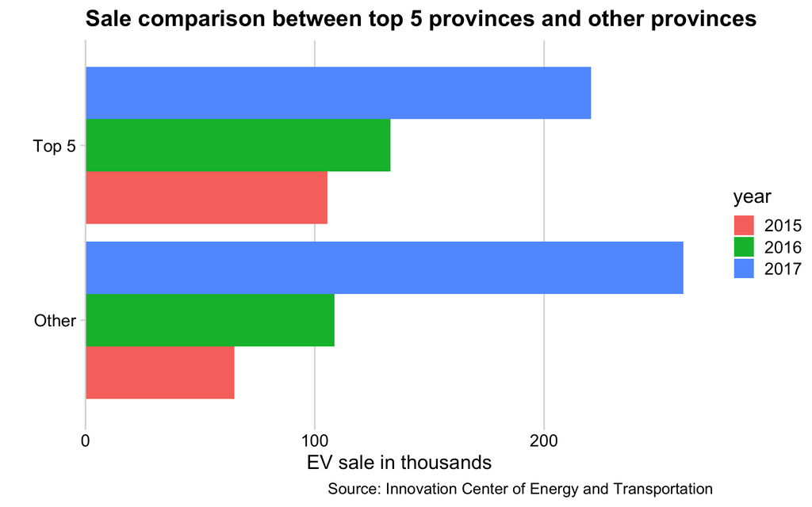

For those two groups, I break down order types into two categories, personal purchases and state purchases. This is determined according to the ownership of the car. I then plot the share of local brand of EV sales based on the province group and order type and the following chart presents the result.

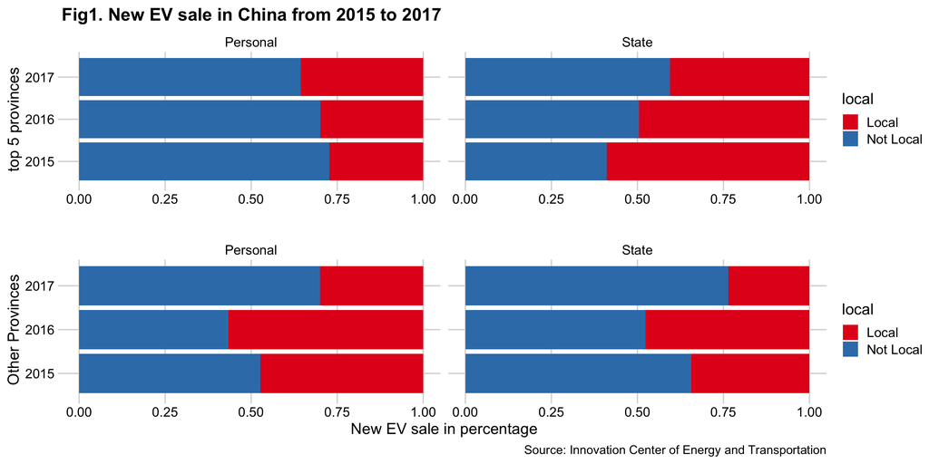

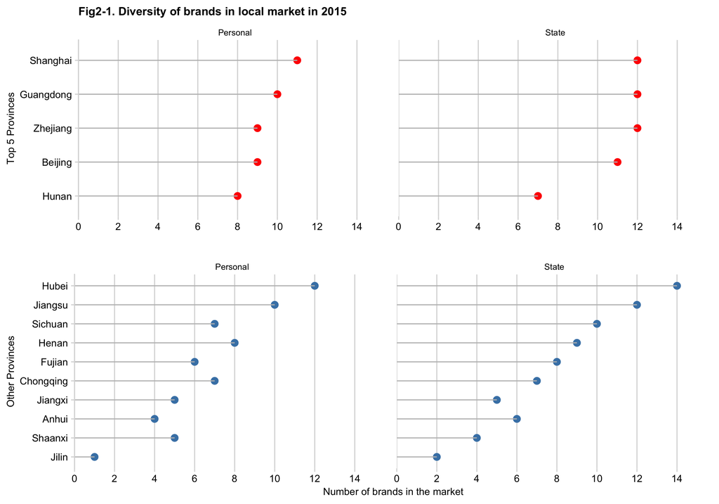

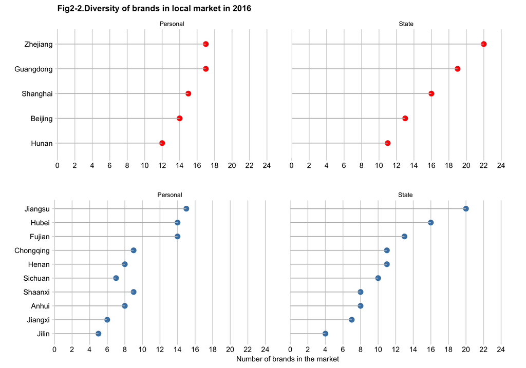

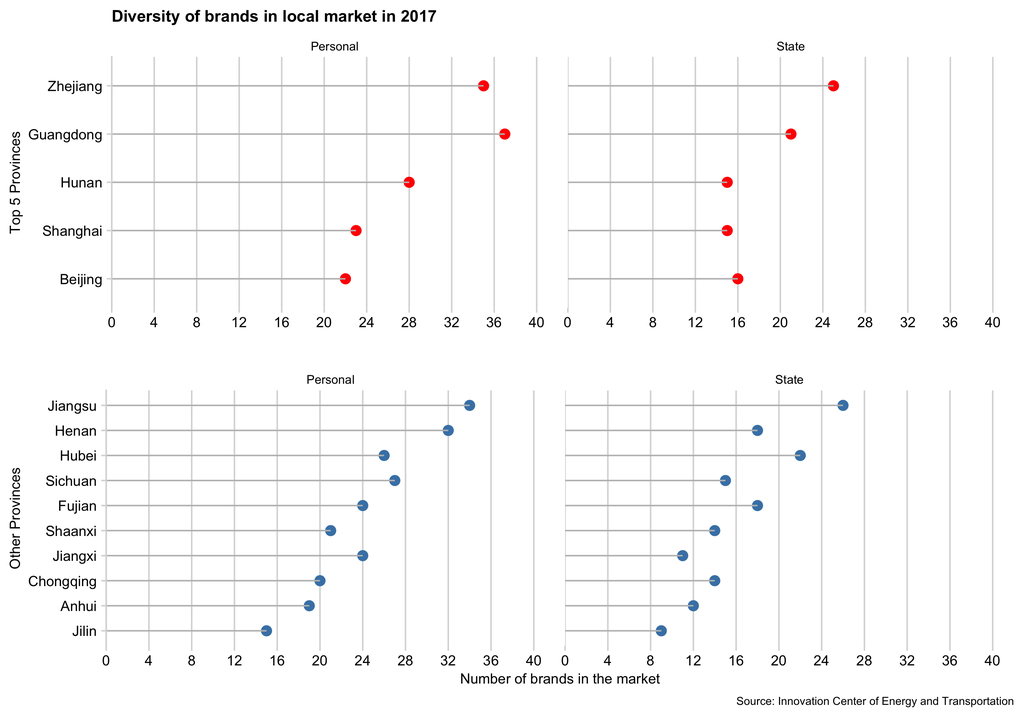

This lack of market diversity in less developed provinces is obvious in the charts above. between 2015 and 2016, top 5 provinces generally have more brands selling in its EV markets and its EV market becomes more and more competitive throughout those three years. The fairly low local brand market share reflects this high competition in the market. In the private side, only 2 to 3 other provinces out of 10 have similar brand diversity as a top 5 province. The brand diversity of other provinces catch up in 2017 and this is reflected on the decrease of local brand market share. So it is clear that high brand diversity is related to a lower local brand market share which is reasonable since the market becomes more and more competitive.

Finally, if we take a closer look at less developed provinces, we will see that even with a diversified EV market like top 5 provinces’, local protectionism could still play an important role there. I choose Anhui, Jiangxi, Zhejiang and Beijing here. The first two provinces represent less developed province with a big local auto manufactures. Zhejiang represents highly developed province but local auto maker did not start making EV until late 2015. Beijing is a highly developed province with huge EV and auto markets.

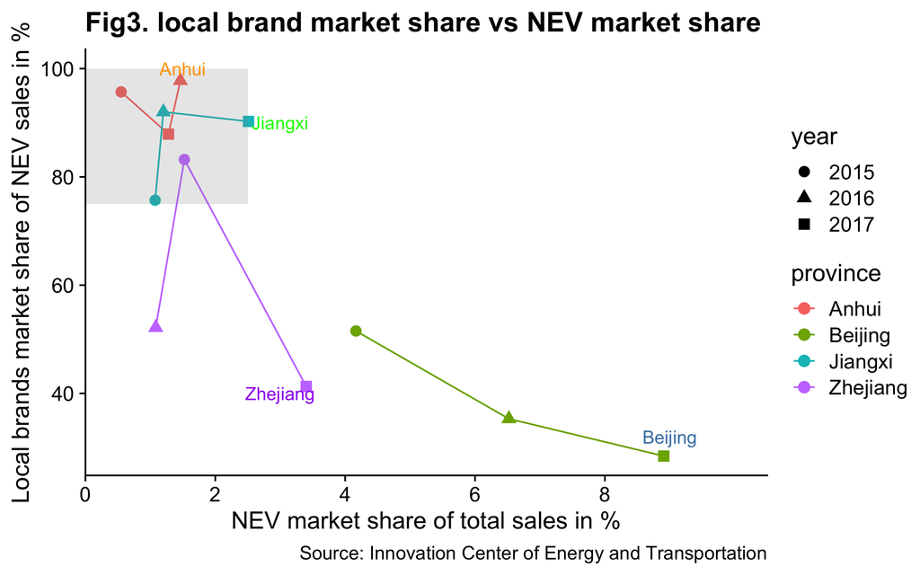

For a less developed province, local auto manufactures are very important source of income to local government and also major employers to the locals. As a result, compared to Beijing and Zhejiang where auto industry is only a piece of their economy, local auto manufactures may gain more influences to government agencies. As the EV market is too small to support all those brands compete with each other, local protectionism will be vital for local brands to survive and Fig3 indicates that a strong protectionism may exist in those less developed provinces.

In conclusion, from the Fig1, we sees that local protectionism may exist in the state purchase and in less developed EV markets. Combined with Fig2, those charts indicate that private purchase in a less developed may be due to low brand diversity. Customers do not have much choices besides local brands and less developed economy in those provinces makes affordability a major concern to the customers too. In the state purchases however, high market diversity does not mean less local brand shares. This indicates a local protectionism from that side of the market. Lastly from Fig3, it indicates that local protectionism may be vital to the survival of local brands in less developed provinces. For provinces like Beijing and Zhejiang, local protectionism may be also important when the EV market is at early stage.

# Appendix

The data includes following variables relative to this study:

from NEV data 2015-2017.xlsx

| variable | description |
| --- | --- |
| Province | Name of the province (in Chinese) |
| City | Name of the city (in Chinese) |
| Year | Year of Purchase |
| Month | Month of incident |
| Model | Model of the EV (Some in Chinese) |
| OEM | Name of the OEM (in Chinese) |
| Amount | Number of NEV sold |
| Ownership | Type of ownership of this NEV (in Chinese) |

from OEM_list.xlsx:

| variable | description |
| --- | --- |
| Province | Name of the province (in Chinese) |
| City | Name of the city (in Chinese) |
| OEM | Name of the OEM (in Chinese) |

from passenger vehicle sales data 2015-2016.xlsx and 2017 passenger vehicle sales.xlsx

| variable | description |
| --- | --- |
| Province | Name of the province (in Chinese) |
| Total | Number of total sale in each province |

```r
# Load libraries and settings here
library(tidyverse)
library(here)
library(readxl)
library(janitor)
library(lubridate)
library(cowplot)
library(viridis)
library(ggpubr)

'%ni%' <- Negate('%in%')
knitr::opts_chunk$set(
    fig.height = 4,
    fig.path = "figs/",
    fig.retina = 3,
    fig.width = 7.252,
    message = FALSE,
    warning = FALSE,
    comment = "#>"
)
# Load data below here
df_evsale_15 <- read_csv(here::here('data_raw','df15.csv'))
df_evsale_16 <- read_csv(here::here('data_raw','df16.csv'))
df_evsale_17 <- read_excel(here::here('data_raw/data-raw','2017 NEV sales data-new.xlsx'))
df_oem <-  read_excel(here::here('data_raw/data-raw','OEM_list.xlsx'))
df_17autosale <- read_excel(here::here('data_raw/data-raw','2017 passenger vehicle sales.xlsx'))
df_15autosale <- read_excel(here::here('data_raw/data-raw','passenger vehicle sales data 2015-2016.xlsx'),sheet='2015')
df_16autosale <- read_excel(here::here('data_raw/data-raw','passenger vehicle sales data 2015-2016.xlsx'),sheet='2016')

colnames(df_17autosale)[1] <- 'province'


# Put any other "global" settings here, e.g. a ggplot theme:
theme_set(theme_bw(base_size = 20))

#rename the oem column
df_oem <- df_oem %>%
  rename(oem_province=省份, oem_city=城市) %>%
  clean_names()

# process sale data
df_evsale_15 <- df_evsale_15 %>%
  select("Year", 'Month','Brand',"Model","OEM","Province" ,"amount","ownership" )%>%
  clean_names()

df_evsale_17 <- df_evsale_17 %>%
  separate(年月, into = c('year','month'),sep=4) %>%
  select("year",'month', '省份','品牌',"车型","汽车生产企业名称" ,"amount","所有权") %>%
  rename(
    ownership=所有权,
    province=省份,
    brand=品牌,
    model=车型,
    oem=汽车生产企业名称) %>%
  mutate(
    month=as.numeric(month),
    year=as.numeric(year)
  ) %>%
  clean_names()

df_evsale_16 <- df_evsale_16 %>%
  select("year", 'month','brand2',"model","OEM","province" ,"amount","所有权") %>%
  rename(
    brand=brand2) %>%
  rename(ownership=所有权) %>%
  clean_names()

# merge oem_with local sale number

df_evsale_joint <- rbind(df_evsale_15,df_evsale_16,df_evsale_17)
df_evsale_joint <- df_evsale_joint %>%
  left_join(df_oem,
            by= 'oem') %>%
  mutate(
    local=ifelse(province==oem_province,'Local',"Not Local")) %>%
  filter(!is.na(ownership),ownership!="未知",!is.na(local))

# get the total auto sale in each province
province_name <-c( unique(df_evsale_joint$province))
df_17autosale <- df_17autosale %>%
  select("province","总计") %>%
  rename(total_sale=总计) %>%
  mutate(year=2017) %>%
  filter(province %in% province_name) %>%
  distinct(province,total_sale,year)

df_15autosale <- df_15autosale %>%
  rename(total_sale=amount,
         province=`Province/city`) %>%
  mutate(year=2015) %>%
  filter(province %in% province_name) %>%
  distinct(province,total_sale,year)

df_16autosale <- df_16autosale %>%
  rename(total_sale=amount,
         province=`Province/city`) %>%
  mutate(year=2016) %>%
  filter(province %in% province_name)

Auto_sale <- rbind(df_15autosale,df_16autosale,df_17autosale)


target_province <- c("北京市",
                     "上海市",
                     "广东省",
                     "浙江省",
                     "湖南省"
                    # "天津市",
                    # "山东省",
                    # "河南省",
                     #"江苏省"
                    # "福建省",
                    # "江西省"
                     )

# target_province <- c("Beijing",
#                      "Shanghai",
#                      "Guangdong",
#                      "Zhejiang",
#                      "Tianjin",
#                      "Shandong",
#                      "Henan",
#                      "Jiangsu",
#                      "Fujian",
#                      "Jiangxi")
# df_evsale_joint$province[df_evsale_joint$province=='北京市'] <-'Beijing'
# df_evsale_joint$province[df_evsale_joint$province=='上海市'] <-'Shanghai'
# df_evsale_joint$province[df_evsale_joint$province=='广东省'] <-'Guangdong'
# df_evsale_joint$province[df_evsale_joint$province=='浙江省'] <-'Zhejiang'
# df_evsale_joint$province[df_evsale_joint$province=='天津市'] <-'Tianjin'
# df_evsale_joint$province[df_evsale_joint$province=='山东省'] <-'Shandong'
# df_evsale_joint$province[df_evsale_joint$province=='河南省'] <-'Henan'
# df_evsale_joint$province[df_evsale_joint$province=='江苏省'] <-'Jiangsu'
# df_evsale_joint$province[df_evsale_joint$province=='福建省'] <-'Fujian'
# df_evsale_joint$province[df_evsale_joint$province=='江西省'] <-'Jiangxi'
df_evsale_joint$ownership[df_evsale_joint$ownership=='个人'] <-'Personal'
df_evsale_joint$ownership[df_evsale_joint$ownership=='单位'] <-'State'
temp <- df_evsale_joint %>%
  group_by(year,province,local) %>%
  summarise(amount=sum(amount)) %>%
  filter(amount!=0,year==2015,local=="Local") %>%
  select(province)
OEM_location <- temp$province


df_evsale_joint %>%
  mutate(
    province=fct_other(province,keep=target_province),
    province=if_else(province!='Other','Top 5','Other')
  ) %>%
  group_by(province,year) %>%
  summarise(amount=sum(amount)/1000) %>%
  ungroup() %>%
  mutate(
    year=as_factor(year),
    province=fct_reorder2(province, year, amount,)) %>%
  ggplot()+
  geom_col(aes(x=amount,y=province,fill=year),position='dodge')+
  theme_minimal_vgrid()+
  scale_x_continuous(
    expand = expand_scale(mult = c(0, 0.05)),

  )+
  labs(
    x='EV sale in thousands',
    y='',
    title='Sale comparison between top 5 provinces and other provinces ',
    caption = 'Source: Innovation Center of Energy and Transportation'
  )

#Plot 1 State VS Personal ownership
plot1 <- df_evsale_joint %>%
  filter(province%in% target_province,province%in% OEM_location) %>%
  mutate(
    year=as.factor(year)
    )%>%
  group_by(year,ownership,local) %>%
  summarise(amount=sum(amount)) %>%
  group_by(year,ownership) %>%
  summarise(pct=amount/sum(amount),local=local) %>%
  mutate(label=str_c(round(pct*100,digits = 2),'%')) %>%
  ggplot()+
  geom_col(aes(x=pct,y=year,fill=local))+
  # geom_text(
  # aes(x = 1-pct+0.1, y = year, label = label),
  # color = "white", size = 6)+
  scale_fill_brewer(palette="Set1")+
  theme_minimal_grid(font_size = 12)+
  facet_wrap(~ownership, ncol=5)+
  labs(
    x='',
    y='top 5 provinces',
    title = "Fig1. New EV sale in China from 2015 to 2017"
  )
```

```r
plot2 <-  df_evsale_joint %>%
  filter(province%ni% target_province,province %in% OEM_location) %>%
  mutate(
    year=as.factor(year)
    )%>%
  group_by(year,ownership,local) %>%
  summarise(amount=sum(amount)) %>%
  group_by(year,ownership) %>%
  summarise(pct=amount/sum(amount),local=local) %>%
  mutate(label=str_c(round(pct*100,digits = 2),'%')) %>%
  ggplot()+
  geom_col(aes(x=pct,y=year,fill=local))+
  theme_minimal_grid(font_size = 12)+
  scale_fill_brewer(palette="Set1")+
  facet_wrap(~ownership, ncol=5)+
  labs(
    x='New EV sale in percentage',
    y ='Other Provinces',
    caption = 'Source: Innovation Center of Energy and Transportation'
  )

figure <- ggarrange(plot1, plot2,nrow=2)
figure
# Plot 2 Brand Diversity
plot_2015_1 <- df_evsale_joint %>%
  filter(province%in% target_province, province%in% OEM_location,year==2015) %>%
  distinct(year, province, ownership, brand, local) %>%
  group_by(year, province,ownership) %>%
  summarise(brand_number=length(unique(brand)),
            local_brand=length(which(local=="Local"))) %>%
  ungroup() %>%
  mutate(label=str_c(round((local_brand/brand_number)*100,digits = 2),'%'),
      province=case_when(
      province=="北京市"~'Beijing',
      province=="上海市"~'Shanghai',
      province=="广东省"~'Guangdong',
      province=="湖南省"~'Hunan',
      province=="浙江省"~'Zhejiang'
    ),
       province=fct_reorder(province,brand_number,)
    ) %>%
  ggplot()+
  geom_point(aes(x=brand_number,y=province),size=3,color='red')+
  geom_segment(aes(x=0,xend=brand_number,y=province,yend=province),color='grey')+
  # geom_vline(
  #   xintercept = ,
  #   color = 'red', linetype = 'dashed') +
  facet_wrap(~ownership,ncol = 2)+
  theme_minimal_vgrid()+
  # geom_text(
  #   aes(x = brand_number+2, y = province, label = label),
  #   color = "black", size = 6)+
  scale_x_continuous(
    breaks = (seq(0, 14, by = 2)),
    limits = c(0,15),
    expand = expand_scale(mult = c(0, 0.05))
  )+
  theme(text = element_text(size=10),
        axis.text.x = element_text( size = 10),
        axis.text.y = element_text( size = 10)) +
  labs(
    x='',
    y='Top 5 Provinces',
    title = 'Fig2-1. Diversity of brands in local market in 2015'
  )

plot_2015_2 <- df_evsale_joint %>%
  filter(province%ni% target_province, province%in% OEM_location,year==2015) %>%
  distinct(year, province, ownership, brand, local) %>%
  group_by(year, province,ownership) %>%
  summarise(brand_number=length(unique(brand)),
            local_brand=length(which(local=="Local"))) %>%
  ungroup() %>%
  mutate(
      label=str_c(round((local_brand/brand_number)*100,digits = 2),'%'),
      province=case_when(
                      province=="吉林省"~'Jilin',
                      province=="四川省"~'Sichuan',
                      province=="安徽省"~'Anhui',
                      province=="江西省"~'Jiangxi',
                      province=="河南省"~'Henan',
                      province=="江苏省"~'Jiangsu',
                      province=="湖北省"~'Hubei',
                      province=="福建省"~'Fujian',
                      province=="重庆市"~'Chongqing',
                      province=="陕西省"~'Shaanxi'
                      ),
      province=fct_reorder(province,brand_number)
    ) %>%
  ggplot()+
  geom_point(aes(x=brand_number,y=province),size=3,color='steelblue')+
  geom_segment(aes(x=0,xend=brand_number,y=province,yend=province),color='grey')+
  # geom_text(
  #   aes(x = brand_number+2, y = province, label = label),
  #   color = "black", size = 6)+
  facet_wrap(~ownership,ncol = 2)+
  theme_minimal_vgrid()+
  scale_x_continuous(
    breaks = (seq(0, 14, by = 2)),
    limits = c(0,15),
    expand = expand_scale(mult = c(0, 0.05))
  )+
  theme(text = element_text(size=10),
        axis.text.x = element_text( size = 10),
        axis.text.y = element_text( size = 10)) +
  labs(
    x='Number of brands in the market',
    y='Other Provinces'
  )
figure1 <- ggarrange(plot_2015_1, plot_2015_2,nrow=2)
figure1
# Plot 2 Brand Diversity
plot_2016_1 <- df_evsale_joint %>%
  filter(province%in% target_province, province%in% OEM_location,year==2016) %>%
  distinct(year, province, ownership, brand, local) %>%
  group_by(year, province,ownership) %>%
  summarise(brand_number=length(unique(brand)),
            local_brand=length(which(local=="Local"))) %>%
  ungroup() %>%
  mutate(label=str_c(round((local_brand/brand_number)*100,digits = 2),'%'),
      province=case_when(
      province=="北京市"~'Beijing',
      province=="上海市"~'Shanghai',
      province=="广东省"~'Guangdong',
      province=="湖南省"~'Hunan',
      province=="浙江省"~'Zhejiang'
    ),
  province=fct_reorder(province,brand_number,)
    ) %>%
  ggplot()+
  geom_point(aes(x=brand_number,y=province),size=3,color='red')+
  geom_segment(aes(x=0,xend=brand_number,y=province,yend=province),color='grey')+
  facet_wrap(~ownership,ncol = 2)+
  theme_minimal_vgrid()+
  # geom_text(
  #   aes(x = brand_number+2, y = province, label = label),
  #   color = "black", size = 6)+
  scale_x_continuous(
    breaks = (seq(0, 25, by = 2)),
    limits = c(0,25),
    expand = expand_scale(mult = c(0, 0.05))
  )+
  theme(text = element_text(size=10),
        axis.text.x = element_text( size = 10),
        axis.text.y = element_text( size = 10)) +
  labs(
    x='',
    y='',
    title = 'Fig2-2.Diversity of brands in local market in 2016'
  )

plot_2016_2 <- df_evsale_joint %>%
  filter(province%ni% target_province, province%in% OEM_location,year==2016) %>%
  distinct(year, province, ownership, brand, local) %>%
  group_by(year, province,ownership) %>%
  summarise(brand_number=length(unique(brand)),
            local_brand=length(which(local=="Local"))) %>%
  ungroup() %>%
  mutate(
      label=str_c(round((local_brand/brand_number)*100,digits = 2),'%'),
      province=case_when(
                      province=="吉林省"~'Jilin',
                      province=="四川省"~'Sichuan',
                      province=="安徽省"~'Anhui',
                      province=="江西省"~'Jiangxi',
                      province=="河南省"~'Henan',
                      province=="江苏省"~'Jiangsu',
                      province=="湖北省"~'Hubei',
                      province=="福建省"~'Fujian',
                      province=="重庆市"~'Chongqing',
                      province=="陕西省"~'Shaanxi'
                      ),
      province=fct_reorder(province,brand_number)
    ) %>%
  ggplot()+
  geom_point(aes(x=brand_number,y=province),size=3,color='steelblue')+
  geom_segment(aes(x=0,xend=brand_number,y=province,yend=province),color='grey')+
  # geom_text(
  #   aes(x = brand_number+2, y = province, label = label),
  #   color = "black", size = 6)+
  facet_wrap(~ownership,ncol = 2)+
  theme_minimal_vgrid()+
  scale_x_continuous(
    breaks = (seq(0, 25, by = 2)),
    limits = c(0,25),
    expand = expand_scale(mult = c(0, 0.05))
  )+
  theme(text = element_text(size=10),
        axis.text.x = element_text( size = 10),
        axis.text.y = element_text( size = 10)) +
  labs(
    x='Number of brands in the market',
    y=''
  )
figure2 <- ggarrange(plot_2016_1, plot_2016_2,nrow=2)
figure2
```

```r
# Plot 2 Brand Diversity
plot_2017_1 <- df_evsale_joint %>%
  filter(province%in% target_province, province%in% OEM_location,year==2017) %>%
  distinct(year, province, ownership, brand, local) %>%
  group_by(year, province,ownership) %>%
  summarise(brand_number=length(unique(brand)),
            local_brand=length(which(local=="Local"))) %>%
  ungroup() %>%
  mutate(label=str_c(round((local_brand/brand_number)*100,digits = 2),'%'),
      province=case_when(
      province=="北京市"~'Beijing',
      province=="上海市"~'Shanghai',
      province=="广东省"~'Guangdong',
      province=="湖南省"~'Hunan',
      province=="浙江省"~'Zhejiang'
    ),
  province=fct_reorder(province,brand_number,)
    ) %>%
  ggplot()+
  geom_point(aes(x=brand_number,y=province),size=3,color='red')+
  geom_segment(aes(x=0,xend=brand_number,y=province,yend=province),color='grey')+
  # geom_text(
  #   aes(x = brand_number+5, y = province, label = label),
  #   color = "black", size = 6)+
  facet_wrap(~ownership,ncol = 2)+
  theme_minimal_vgrid()+
  scale_x_continuous(
    breaks = (seq(0, 40, by = 4)),
    limits = c(0,40),
    expand = expand_scale(mult = c(0, 0.05))
  )+
  theme(text = element_text(size=10),
        axis.text.x = element_text( size = 10),
        axis.text.y = element_text( size = 10)) +
  labs(
    x='',
    y='Top 5 Provinces',
    title = 'Diversity of brands in local market in 2017'
  )

plot_2017_2 <- df_evsale_joint %>%
  filter(province%ni% target_province, province%in% OEM_location,year==2017) %>%
  distinct(year, province, ownership, brand, local) %>%
  group_by(year, province,ownership) %>%
  summarise(brand_number=length(unique(brand)),
            local_brand=length(which(local=="Local"))) %>%
  ungroup() %>%
  mutate(
      label=str_c(round((local_brand/brand_number)*100,digits = 2),'%'),
      province=case_when(
                      province=="吉林省"~'Jilin',
                      province=="四川省"~'Sichuan',
                      province=="安徽省"~'Anhui',
                      province=="江西省"~'Jiangxi',
                      province=="河南省"~'Henan',
                      province=="江苏省"~'Jiangsu',
                      province=="湖北省"~'Hubei',
                      province=="福建省"~'Fujian',
                      province=="重庆市"~'Chongqing',
                      province=="陕西省"~'Shaanxi'
                      ),
      province=fct_reorder(province,brand_number)
    ) %>%
  ggplot()+
  geom_point(aes(x=brand_number,y=province),size=3,color='steelblue')+
  geom_segment(aes(x=0,xend=brand_number,y=province,yend=province),color='grey')+
  # geom_text(
  #   aes(x = brand_number+5, y = province, label = label),
  #   color = "black", size = 6)+
  facet_wrap(~ownership,ncol = 2)+
  theme_minimal_vgrid()+
  scale_x_continuous(
    breaks = (seq(0, 40, by = 4)),
    limits = c(0,40),
    expand = expand_scale(mult = c(0, 0.05))
  )+
  theme(text = element_text(size=10),
        axis.text.x = element_text( size = 10),
        axis.text.y = element_text( size = 10)) +
  labs(
    x='Number of brands in the market',
    y='Other Provinces',
    caption = 'Source: Innovation Center of Energy and Transportation'
  )
figure3 <- ggarrange(plot_2017_1, plot_2017_2,nrow=2)
figure3
#plot 3 big manufactures in small markets
target_province <- c("北京市",
                     #"上海市",
                     "安徽省",
                     "江西省",
                     "浙江省"
                     )
NEV_sale <- df_evsale_joint %>%
  filter(province%in% target_province) %>%
  group_by(year,province,local) %>%
  summarise(amount=sum(amount)) %>%
  group_by(year,province) %>%
  summarise(pct=100*amount/sum(amount),local=local)%>%
  filter(local=='Local')

total_auto_sale <- Auto_sale %>%
  filter(province%in% target_province) %>%
  group_by(year,province) %>%
  summarise(total_sale=sum(total_sale))

NEV_sale_pct <- df_evsale_joint %>%
  filter(province%in% target_province) %>%
  group_by(year,province) %>%
  summarise(amount=sum(amount)) %>%
  left_join(total_auto_sale,by=c('province','year')) %>%
  mutate(auto_sale_pct=100*amount/total_sale)

NEV_sale %>%
  left_join(NEV_sale_pct,by=c('province','year')) %>%

  mutate(
    province=case_when(
      province=="北京市"~'Beijing',
      province=="上海市"~'Shanghai',
      province=="安徽省"~'Anhui',
      province=="江西省"~'Jiangxi',
      province=="浙江省"~'Zhejiang'

    ),
    year=as.factor(year)
  ) %>%
  select(province,year,pct,auto_sale_pct) %>%
  ggplot(aes(x=auto_sale_pct,y=pct,shape=year,color=province,group=province))+
  geom_line()+
  geom_point(size=3)+
  annotate(geom = "rect",
    xmin = 0, xmax = 2.5,
    ymin = 75, ymax = 100,
    fill = "grey55", alpha = 0.2) +
 #theme_minimal_grid(font_size = 16)+
  theme_half_open(font_size = 15)+
  scale_x_continuous(
  breaks = c(0, 2, 4,6, 8),
  limits = c(0 , 10),
  expand = expand_scale(mult = c(0, 0.05)))+
  annotate(geom = 'text', x = 1.5, y = 100,
             label = 'Anhui', size =4 , color = 'orange')+
  annotate(geom = 'text', x = 3, y = 90,
             label = 'Jiangxi', size = 4, color = 'green')+
  annotate(geom = 'text', x = 3, y = 40,
             label = 'Zhejiang', size = 4, color = 'purple')+
  annotate(geom = 'text', x = 9, y =32 ,
             label = 'Beijing', size = 4, color = 'steel blue')+
  #annotate(geom = 'text', x = 11, y = 37,
             #label = 'Shanghai', size = 4, color = 'steel blue')+
  labs(
    x='NEV market share of total sales in %',
    y='Local brands market share of NEV sales in %',
    title = 'Fig3. local brand market share vs NEV market share',
    caption = 'Source: Innovation Center of Energy and Transportation'

  )
  #theme(legend.position = 'none')
```